# eHMM manual

[figure not shown]

## Overview

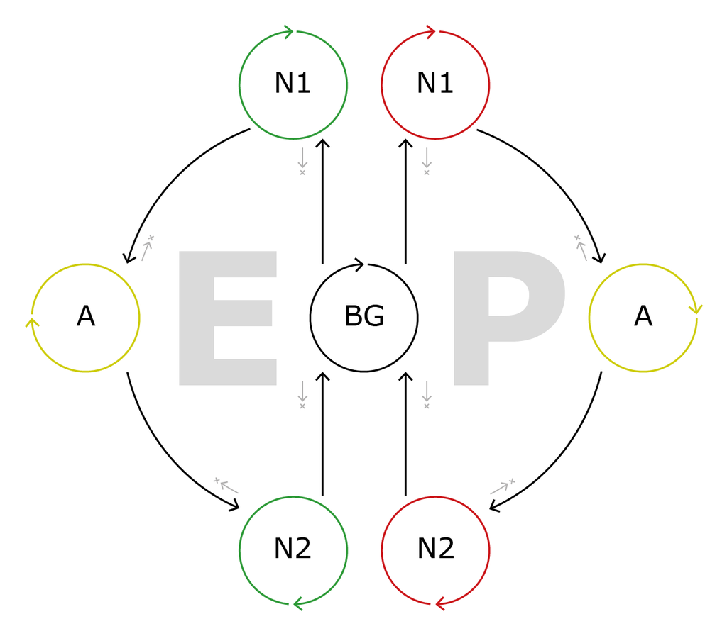

eHMM (enhancer Hidden Markov Model) is a software for genome-wide enhancer prediction based on the state of the chromatin. It uses an updated framework of EpiCSeg (Mammana et al., 2015) which provides tools for extracting count data from BAM files, typlically corresponding to ChIP-seq experiments for histone marks (but other choices are possible) learns a statistical model for the read counts based on a HMM, and provides tools for displaying and analyzing the obtained models and segmentations. eHMM learns an unsupervised background model as well as two foreground models based on training sets for enhancers and promoters, thereby distinguishing between the two. eHMM can also be used with pretrained models. eHMM can be used as an R package or from the command line via Rscript.

### About this manual

There are three parts:

1. the installation part describes how to setup eHMM
2. the subprograms part describes in detail how to use each subprogram
3. the usage examples part shows some basic examples to get started and discusses potential issues

For a more flexible usage try out the R functions.

## eHMM

For using eHMM from the command line, you can find the full manual HERE!

### Installation

`ehmm` needs R 3.2 (or newer) and depends on Bioconductor packages, CRAN packages, and another package from github. For the installation, most of the work is done by the function `devtools::install_github`. Because lately this function cannot resolve Bioconductor dependencies anymore (see this issue: https://github.com/hadley/devtools/issues/700), we will need to install some Bioconductor packages manually.

The Bioconductor dependencies are `IRanges`, `GenomicRanges`, `bamsignals` and `edgeR`. At the interactive R terminal, type:

```r
source("http://bioconductor.org/biocLite.R")
biocLite(c("IRanges", "GenomicRanges", "bamsignals", "edgeR"))
```

Install and load the `devtools` package to be able to directly install R packages hosted on github :

```r
install.packages("devtools")
library(devtools)
```

To install `ehmm` type:

```r
install_github("tobiaszehnder/ehmm")
```

### Usage from the command line

To use eHMM from the command line, you need to:

1. create a launcher to be used with Rscript. This is done by typing `ehmm:::getLauncher("ehmm.R")` at the R interactive terminal, which will create the file `ehmm.R` in your working directory. You can move and rename this file the way you want.
2. To use it, type `Rscript ehmm.R subprogram arguments`. In UNIX you can also simply do `./ehmm.R subprogram arguments` provided that you have execution permission on the file `.ehmm.R`.
3. To see what the available subprograms are, simply type: `Rscript ehmm.R`
4. To see which arguments each subprogram needs, you can type: `Rscript ehmm.R subprogram`

## Subprograms

learnModel

Learn an unsupervised HMM for a given set of genomic regions and feature bam files

Required arguments

--regions REGIONS, -r REGIONS

Path to the BED file with the genomic regions of interest. These regions will be automatically partitioned into smaller, consecutive bins. Only the first three fields in the file matter. If the region lengths are not multiples of the given binsize a new bed file will be produced where each coordinate is a multiple of binsize. Use this new file together with the count matrix for later analyses.

--nstates NSTATES, -n NSTATES

Number of states to use for training

--mark LABEL:PATH, -m LABEL:PATH (repeatable)

Mark name and path to a bam file where to extract reads from. The bam files must be indexed and the chromosome names must match with those specified in the bed file. Entries with the same mark name will be treated as replicates and collapsed into one experiment.  
This option must be repeated for each mark, for example:  
`-m ATAC-seq:/path1/foo1.bam -m H3K4ME1:/path2/foo2.bam`

Optional arguments

--outdir OUTDIR, -o OUTDIR (default: .)

Path to the output directory.

--nthreads NTHREADS (default: 1)

Number of threads to be used

--pseudoCount PSEUDOCOUNT, -p PSEUDOCOUNT (default: 1)

Pseudo-count added to read-counts for log-normal fit.

constructModel

Construct a full model by combining given models for background, enhancers and promoters

Required arguments

--model.bg MODEL.BG, -m MODEL.BG

Path to the file with the parameters of the background HMM.

--model.e MODEL.E

Path to the file with the parameters of the enhancer HMM.

--model.p MODEL.P

Path to the file with the parameters of the promoter HMM.

--counts.e COUNTS.E, -r COUNTS.E

Path to the countmatrix for the enhancer training regions

--counts.p COUNTS.P

Path to the countmatrix for the promoter training regions

--regions.e REGIONS.E

Path to the BED file with the enhancer training regions associated to the count matrix.

--regions.p REGIONS.P

Path to the BED file with the promoter training regions associated to the count matrix.

Optional arguments

--outdir OUTDIR, -o OUTDIR (default: .)

Path to the output directory.

--nthreads NTHREADS (default: 1)

Number of threads to be used

--accStates.e ACCSTATES.E, -a ACCSTATES.E

String of comma-separated state-numbers for enhancer accessibility states. If not given, states selection will be automated.

--nucStates.e NUCSTATES.E, -n NUCSTATES.E

String of comma-separated state-numbers for enhancer nucleosome states. If not given, states selection will be automated.

--accStates.p ACCSTATES.P

String of comma-separated state-numbers for promoter accessibility states. If not given, states selection will be automated.

--nucStates.p NUCSTATES.P

String of comma-separated state-numbers for promoter nucleosome states. If not given, states selection will be automated.

applyModel

Produce a segmentation based on a given model and extract enhancer / promoter elemenents

Required arguments

--regions REGIONS

Path to the BED file with the genomic regions of interest.

--genomeSize GENOMESIZE, -g GENOMESIZE

Path to a two-column file indicating chromosome names and sizes.

Optional arguments

--model MODEL, -m MODEL

Path to the file with the parameters of the HMM.

--provideModel, -p

Whether or not to use the provided model that was learned on mouse embryonic stem cell data.  
If this flag is set, query data will be normalized to the data that was used during model training.

--counts COUNTS, -r COUNTS

Path to the count matrix. If not given, it will be calculated and written to the output directory.

--mark LABEL:PATH (repeatable)

Mark name and path to a bam file where to extract reads from. Only required if counts are not given.  
The bam files must be indexed and the chromosome names must match with those specified in the bed file.  
Entries with the same mark name will be treated as replicates and collapsed into one experiment.  
This option must be repeated for each mark, for example:  
`--mark H3K4me3:/path1/foo1.bam --mark H3K36me3:/path2/foo2.bam`

--outdir OUTDIR, -o OUTDIR (default: .)

Path to the output directory.

--nthreads NTHREADS (default: 1)

Number of threads to be used

--learnTrans, -l (default: FALSE)

Whether or not to let the model learn the transition probabilities while fixing the emission parameters.

--refCounts REFCOUNTS

Path to the count matrix of the reference model.  
If given, the counts of the query sample will be quantile-normalized to its distribution.  
refCounts should ideally represent a full genome and not just a subset.

## Usage examples

### Prerequisites

1. Use a UNIX system. Windows can also be used, but these examples need to be slightly adapted.
2. Create a launcher called `ehmm.R` using the `ehmm:::getLauncher` function.
3. Add execution permissions to the launcher:

   ```
   chmod 700 ehmm.R
   ```

4. Put the launcher in a folder listed in your `PATH` environment variable:

   ```
   export PATH=/path/to/the/launcher/:$PATH
   ```

### Demo

To get an impression on how to use eHMM, you can run a demo that will download and process bam-files of mouse embryo liver E16.5 cells from ENCODE, and predict enhancers genome-wide.

1. Start `R`
2. Load the package `library(ehmm)`
3. Type `demo('demo', package='ehmm', ask=FALSE)`

### Issues

Did you encounter any issues? Please file an issue in the github repository. Thank you.